# Mi primer notebook

Este es un archivo de ejemplo para revisar las características principales del notebook y cómo trabajar de manera interactiva con Python. Toma en cuenta que el proceso de operación es el mismo que con la consola de Python, cada instrucción requiere su correcta sintaxis, manejo de parámetros, etc. en caso de omitir o excederse en una letra, variable, parámetro, falta de declaración, importación de librerías, tendremos un aviso por parte del programa.

Veamos unos ejemplos simples de operaciones con la librería math

```python
from math import *
```

Es aconsejable anotar dentro de una celda, un conjunto de instrucciones de Python, con la idea de agrupar bloques de trabajo, al principio y con la idea de acostumbrarse al manejo del navegador y del uso de las celdas, se puede anotar en cada celda una instrucción.

```python
print (sqrt(2))
```

```
1.4142135623730951
```

```python
print (abs(-123.456))
```

```
123.456
```

```python
print (log(100))
```

```
4.605170185988092
```

```python
print (log10(100))
```

```
2.0
```

Veamos el caso de cuando hacemos referencia a una librería pero ésta, no se ha invocado inicialmente:

```python
x = linspace(-3,3,100)
```

```
---------------------------------------------------------------------------
NameError                                 Traceback (most recent call last)
 in ()
----> 1 x = linspace(-3,3,100)

NameError: name 'linspace' is not defined
```

Tenemos un error al momento de ejecutar la celda, para resolverlo, mandamos llamar la librería

```python
from numpy import *
import matplotlib.pyplot as plt
```

```python
x = linspace(-3,3,100)
```

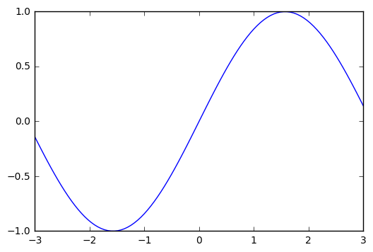

```python
plt.plot(x,sin(x))
plt.show()
```

Buena parte del material que estaremos trabajando para el curso de Física Computacional, lo enviaremos como un archivo notebook. De la misma manera que hemos visto una parte básica de programación con Python, te pedimos que revises y extiendas el uso y el manejo de los notebooks.